# Analysing real catch and effort data: a step-by-step guide

Henning Winker FAO Fisheries and Aquaculture Division, Assessment and Management Team (NFIFM) henning.winker@fao.org

This guide shows how to prepare fishery-dependent catch and effort data for CPUE standardisation when fishers change what they target. It generalises the protocol developed for blackspot seabream (GFCM) to any multispecies fishery, from the raw logbook to the standardised index.

| Step | Question | Functions |
| --- | --- | --- |
| 1. Format | Which column is what? One row per operation? | `cpue_data()`, `subset()` |
| 2. Fleet | Who fished when? Is reporting consistent? Which vessels are indicators? | `plot_fleet()`, `vessel_summary()`, `select_vessels()`, `plot_vessel_profile()` |
| 3. Species | Which species carry the targeting signal? | `species_curve()`, `plot_species_curve()`, `select_species()` |
| 4. Nominal CPUE | What do the raw data say? | `nominal_cpue()`, `plot_nominal()`, `plot_composition()`, `plot_cpue_map()` |
| 5. Subsetting (optional) | Which operations fished the target’s habitat? | `stephens_maccall()`, `plot_stephens_maccall()`, `select_tactics()` (after Step 6) |
| 6. Targeting covariates | How did fishing tactics change? | `add_targeting()`, `plot_oc()`, `plot_biplot()`, `tactic_table()`, `plot_targeting()` |
| 7. Models | Base, Covariates, DPC, Cluster, spatial, vessel effects | `fit_cpue()` |
| 8. Diagnostics | Which terms matter, and do the models fit? Is the error distribution right? | `cpue_diagnostics()`, `plot_index()`, `plot_step()`, `plot_influence()`, `plot_residuals()`, `ppc_cpue()`, `plot_effects()`, `plot_vessel_effects()` |
| 9. Index | The index for the assessment | `cpue_index()`, `export_index()` |

Every step returns the same kind of object, and every step that removes operations writes a line into a processing log, so the final data set can be reported exactly.

## Example data

To show what each step should find, the example uses a logbook generated by the bathymetric simulator (`simulate_bathymetric()`): four species live along a depth gradient and 30 vessels shift effort between them as prices change (years 1-10, 11-20, 21-30). In real data the truth is unknown; here it lets us check that the tools recover the changes in targeting.

We turn the simulation into a typical logbook extract: one row per trip and species, with catch in kg, hours fished, month, a coarse position, two rare bycatch species, and one species recorded under two names.

```r
sim <- simulate_bathymetric(seed = 123)
set.seed(1)
sets <- as_set_data(sim$Data)
sets$hours <- round(runif(nrow(sets), 4, 12), 1)
sets$month <- sample(1:12, nrow(sets), replace = TRUE)
names_sp <- c(Sp1 = "Eopsetta jordani", Sp2 = "Microstomus pacificus",
              Sp3 = "Sebastes crameri", Sp4 = "Anoplopoma fimbria")
long <- do.call(rbind, lapply(names(names_sp), function(s) {
  data.frame(trip = sets$SetID, year = sets$year + 1999, vessel = sets$vessel,
             hours = sets$hours, month = sets$month, lon = sets$Xobs, lat = sets$Yobs,
             species = names_sp[[s]], kg = sets[[s]] * sets$hours)
}))
# rare bycatch and a synonym
rare <- data.frame(trip = sample(sets$SetID, 400), species = "Raja spp.", kg = rexp(400))
rare2 <- data.frame(trip = sample(sets$SetID, 80), species = "Squalus suckleyi", kg = rexp(80))
extra <- rbind(rare, rare2)
extra <- cbind(long[match(extra$trip, long$trip), c("year", "vessel", "hours", "month",
                                                    "lon", "lat")], extra)
long <- rbind(long, extra[, names(long)])
syn <- long$species == "Anoplopoma fimbria" & runif(nrow(long)) < 0.1
long$species[syn] <- "Sablefish"
logbook <- long[long$kg > 0, ]
head(logbook)
```

```
##   trip year vessel hours month  lon lat          species           kg
## 1    1 2000      6   6.1    10  8.5 3.5 Eopsetta jordani 386.36821205
## 3    3 2000      3   8.6    12 23.5 3.5 Eopsetta jordani   0.04827733
## 4    4 2000     10  11.3     1 43.5 3.5 Eopsetta jordani   4.19410019
## 6    6 2000     21  11.2    12  8.5 3.5 Eopsetta jordani 535.39500130
## 7    7 2000     14  11.6     4  8.5 3.5 Eopsetta jordani 345.30096240
## 8    8 2000     17   9.3     6 18.5 3.5 Eopsetta jordani  78.78594164
```

## Step 1. Format the data

`cpue_data()` takes the logbook in long format (one row per operation and species, as above) or wide format (one row per operation, one column per species) and returns one row per operation. Tell it which column plays which role.

```r
x <- cpue_data(logbook, year = "year", species = "species", catch = "kg",
               effort = "hours", id = "trip", vessel = "vessel",
               lon = "lon", lat = "lat", covariates = "month",
               synonyms = c("Sablefish" = "Anoplopoma fimbria"))
x
```

```
## <cpue_data> 12799 operations, 6 species, years 2000 - 2029
##   vessels: 30
##   effort: hours
##   position: lon / lat
##   covariates: month
##   main species: Microstomus pacificus, Anoplopoma fimbria, Eopsetta jordani, Sebastes crameri, Raja spp. ...
## Processing log:
##                 step operations                     note
##  input (long format)      12799 44049 records, 6 species
```

> **Guidelines**
> - Define the **operation** carefully: the unit at which effort and catch composition are recorded (set, haul, fishing day or trip). Catch composition reflects targeting best at the finest unit available; trips that span several fishing grounds or gears mix tactics.
> - Choose an **effort** measure that scales catch (hours fished, hooks, days at sea). Without effort, the catch per operation is used.
> - Merge **synonyms** and drop non-informative categories (bait, discards, “unidentified”) before anything else; they change the species set.
> - Use `subset()` for any further rule (e.g. single-day trips, a gear, a period). Each call is recorded in the log.

```r
x <- subset(x, month %in% 1:12, note = "all months (example)")
```

## Step 2. Explore the fleet

Standardisation corrects for the non-random allocation of effort. First look at how operations are spread over years and vessels.

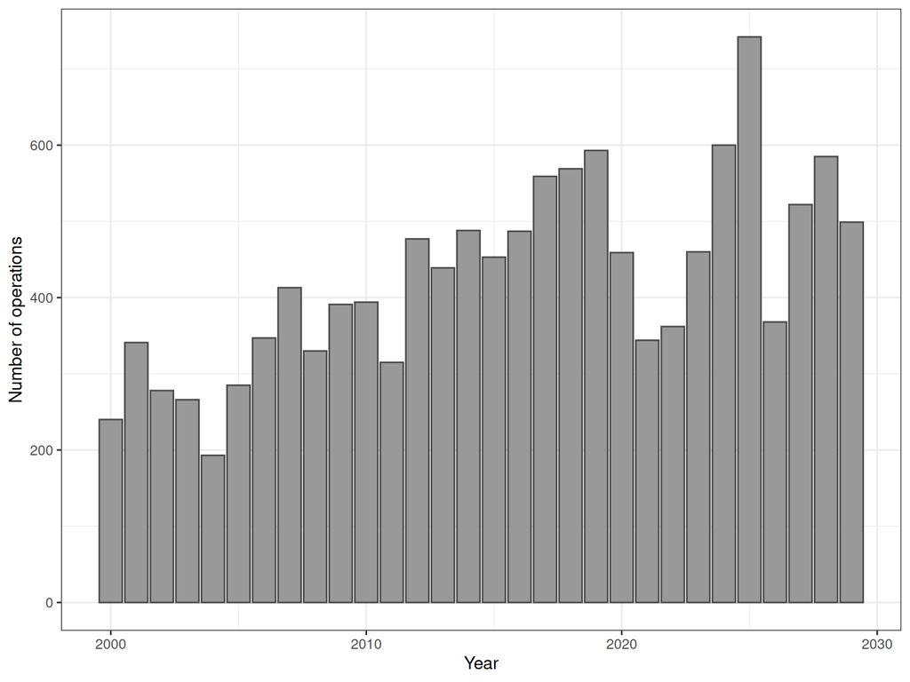

```r
fl <- plot_fleet(x, by = "month")
fl$records
```

[figure not shown]

```r
fl$vessels
```

[figure not shown]

```r
fl$vessel_years
```

[output not shown]

> **Guidelines**
> - Strong **fleet turnover** (new vessels replacing old ones) confounds vessel efficiency with year; random vessel effects help, but only if vessels overlap in time.
> - An **indicator fleet** of vessels that fished consistently can make reporting more homogeneous. `select_vessels(x, min_years, min_records)` keeps vessels with at least `min_records` operations in at least `min_years` years. Compare indices with and without the selection.
> - Rules on the **target species** keep vessels that fish its habitat regularly: `target`, `min_years_target` (years with catches of the target), `min_share_target` (share of the vessel’s operations catching it) and `min_catch_target`. `vessel_summary()` lists these quantities for every vessel and `plot_vessel_profile()` shows each vessel’s catch split by species or species group, which separates specialists from mixed vessels. Rules on the target select vessels by their catches of it: prefer rules on years active and on the share of operations, and always compare with the index of all vessels.

```r
x_core <- select_vessels(x, min_years = 10, min_records = 5)
x_core$log
```

```
##                  step operations
## 1 input (long format)      12799
## 2 select core vessels      12799
##                                                           note
## 1                                     44049 records, 6 species
## 2 30 of 30 vessels (>= 10 years with >= 5 records) (0 removed)
```

```r
vs <- vessel_summary(x, target = "Anoplopoma fimbria")
head(vs)
```

```
##   vessel records years years_qualified first last records_target share_target
## 1     10     470    30              30  2000 2029            373    0.7936170
## 2     23     466    30              30  2000 2029            374    0.8025751
## 3     28     456    30              30  2000 2029            416    0.9122807
## 4     11     451    30              30  2000 2029            413    0.9157428
## 5     14     448    30              30  2000 2029            376    0.8392857
## 6      1     443    30              30  2000 2029            350    0.7900677
##   years_target catch_target
## 1           30     18899.91
## 2           30     20474.02
## 3           30     30760.53
## 4           30     31132.41
## 5           30     22601.00
## 6           30     18512.00
```

```r
x_target <- select_vessels(x, min_years = 10, min_records = 5,
                           target = "Anoplopoma fimbria", min_share_target = 0.3)
table(attr(x_target, "vessels")$selected)
```

```
##
## TRUE
##   30
```

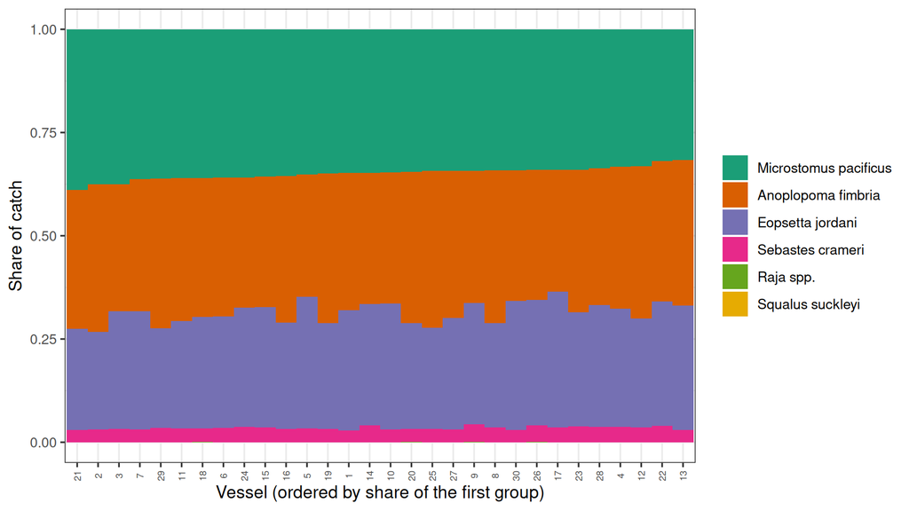

```r
plot_vessel_profile(x)
```

## Step 3. Choose the species set

The catch composition carries the targeting signal, but rare species add noise and many zero proportions. The cumulative species curve ranks species by how often they are recorded; the species needed to reach a cumulative share (95% by default) form the species set.

```r
species_curve(x)
```

```
##                 species                 label rank value       share cumulative
## 1 Microstomus.pacificus Microstomus pacificus    1 10954 0.248677609  0.2486776
## 2      Sebastes.crameri      Sebastes crameri    2 10905 0.247565211  0.4962428
## 3    Anoplopoma.fimbria    Anoplopoma fimbria    3 10861 0.246566324  0.7428091
## 4      Eopsetta.jordani      Eopsetta jordani    4 10849 0.246293900  0.9891030
## 5             Raja.spp.             Raja spp.    5   400 0.009080796  0.9981838
## 6      Squalus.suckleyi      Squalus suckleyi    6    80 0.001816159  1.0000000
```

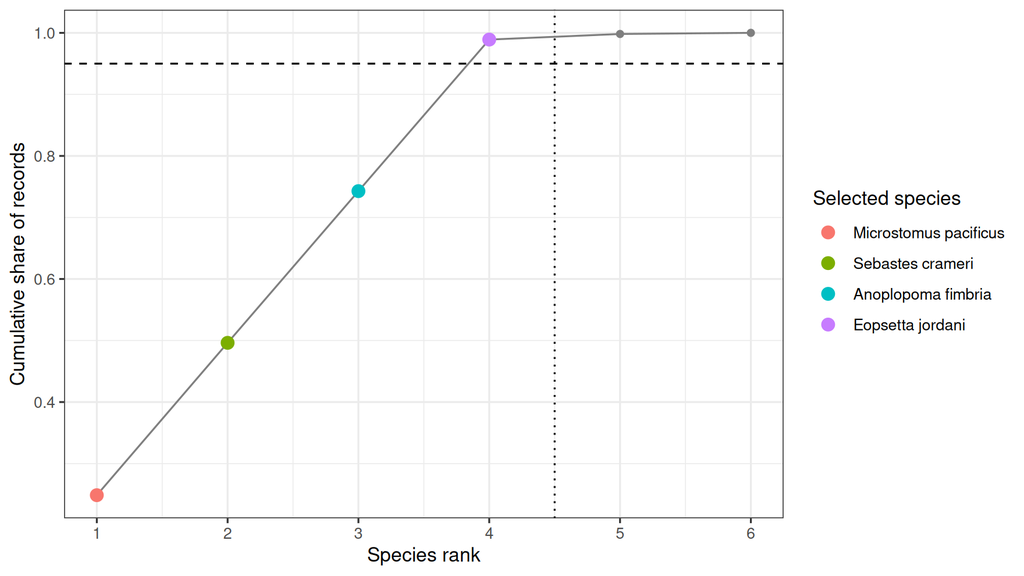

```r
plot_species_curve(x, threshold = 0.95)
```

```r
x <- select_species(x, threshold = 0.95)
x$species_labels
```

```
##   Microstomus.pacificus        Sebastes.crameri      Anoplopoma.fimbria
## "Microstomus pacificus"      "Sebastes crameri"    "Anoplopoma fimbria"
##        Eopsetta.jordani
##      "Eopsetta jordani"
```

> **Guidelines**
> - Use **occurrence** (default) as the main criterion and check `by = "weight"`: a species caught rarely but in large amounts can be a target of a distinct tactic.
> - Always **keep the species of interest** (`keep = "..."`), even if rare.
> - Species that are characteristic of other tactics are valuable even when not abundant; they are what lets the PCA separate tactics.
> - `pool_other = TRUE` keeps the dropped species as one `Other` column. Try it if many operations would be lost.
> - Operations that caught none of the selected species are removed (their composition is undefined). The log reports how many.

## Step 4. Nominal CPUE and catch composition

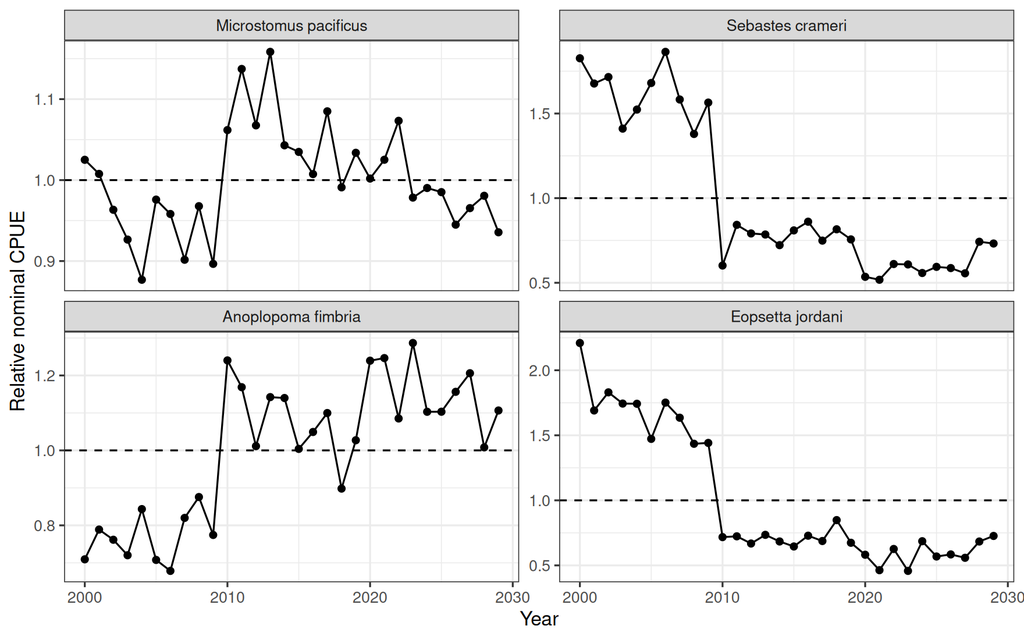

```r
nom <- plot_nominal(x)
nom$index
```

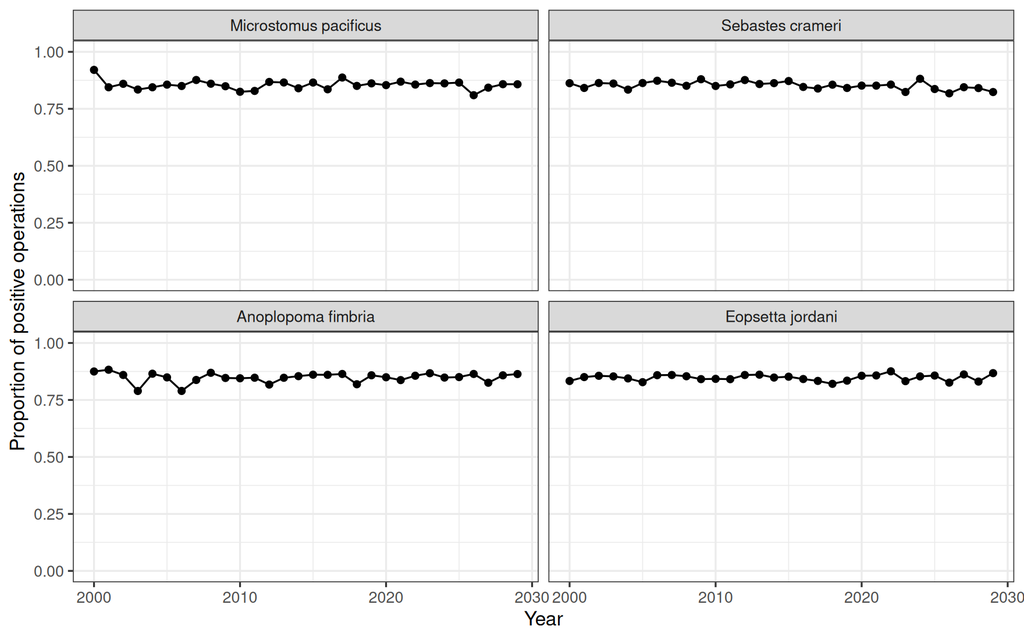

```r
nom$positive
```

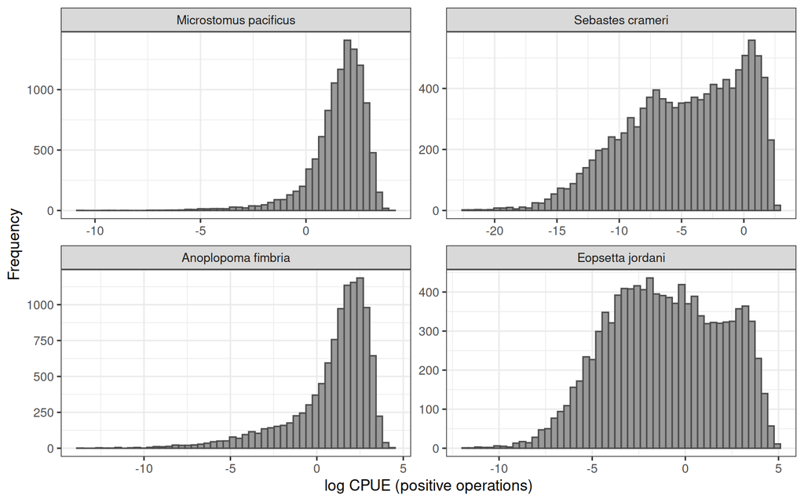

```r
nom$distribution
```

Changes in the catch composition over time are the first sign of changes in targeting (or of diverging trends in abundance).

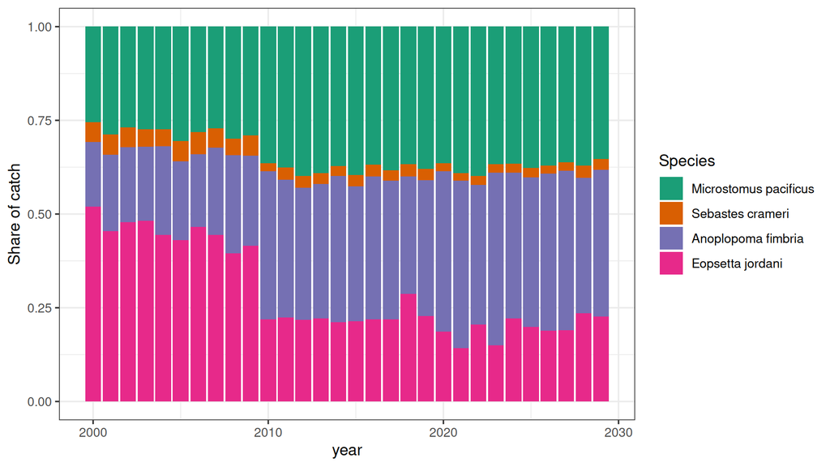

```r
plot_composition(x)
```

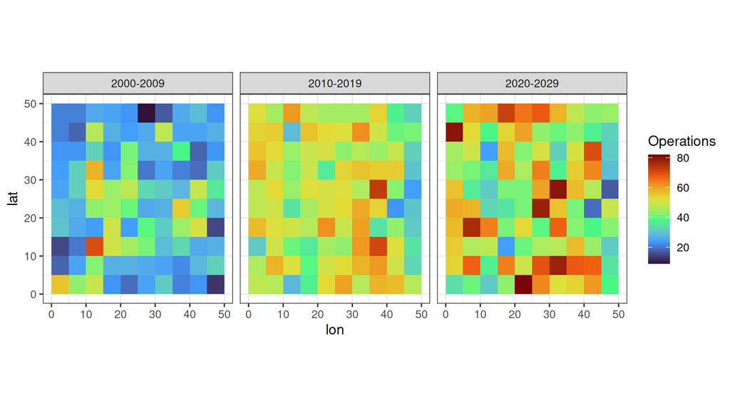

```r
plot_cpue_map(x, res = 5, by_period = 10)
```

In this simulation prices change in 2010 and 2020 while the true biomass trends change smoothly, so shifts in composition at those years reflect targeting.

> **Guidelines**
> - Look at the **proportion of positive operations** and the **distribution of positive CPUE**; they guide the choice between a Tweedie and a delta model.
> - Abrupt changes in composition that coincide with regulations, markets or gear changes point to targeting, not abundance.

## Step 5. Habitat-based subsetting (optional)

Stephens and MacCall (2004) keep only operations likely to have fished the habitat of the target species, predicted from the presence of the other species with a binomial GLM. It is useful when many operations could not have caught the species at all.

Here we use the least frequently recorded of the selected species as the target.

```r
target <- tail(species_curve(x)$label, 1)
target
```

```
## [1] "Eopsetta jordani"
```

```r
sm <- stephens_maccall(x, target = target)
sm
```

```
## <stephens_maccall> target: Eopsetta jordani
##   critical probability: 0.83
##   operations kept: 10905 of 12798 (85%)
##   target present in 85% of kept and 83% of dropped operations
```

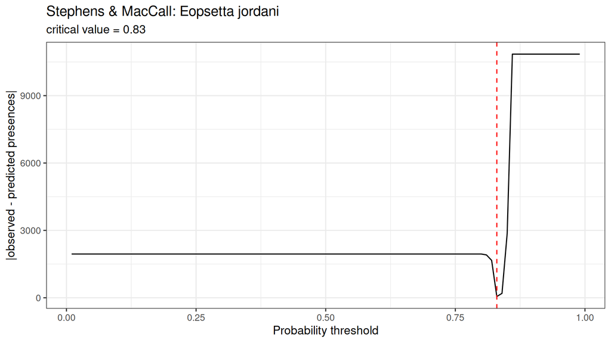

```r
pl <- plot_stephens_maccall(sm)
pl$threshold
```

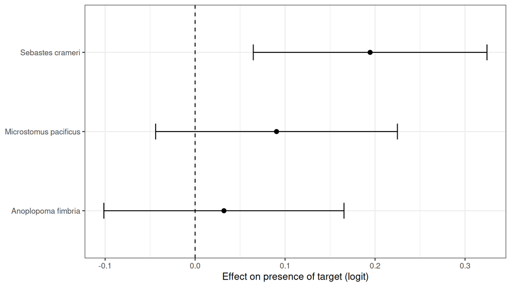

```r
pl$coefficients
```

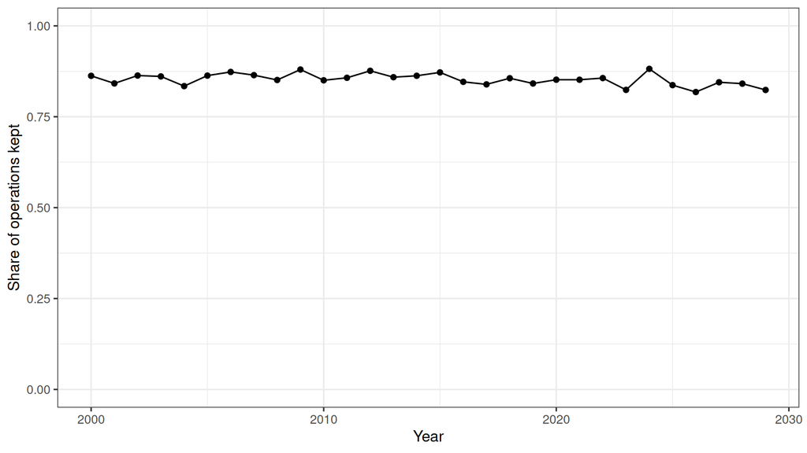

```r
pl$kept
```

```r
x_sm <- subset(x, sm$selected, note = paste("Stephens & MacCall,", target))
```

> **Guidelines**
> - Subsetting **discards data** and the subset is defined by the catch composition, so it can change over time with targeting. Check `pl$kept`: a trend in the share of operations kept means the subset itself follows the targeting.
> - It removes operations that could not catch the species, but it does not correct for different catch rates **within** the habitat; combine it with the targeting covariates of Step 6 when targeting varies within the subset.
> - The method needs a target that is absent from a fair share of operations.

## Step 6. Targeting covariates from the catch composition

`add_targeting()` converts the catch of each operation into proportions, applies a fourth-root transformation, runs a PCA, chooses the number of non-trivial PCs with the Optimal Coordinates test, and clusters the operations into fishing tactics (`n_pc + 1` clusters, Winker et al. 2014). It adds the PC scores (`PC1`, `PC2`, …) and the tactic (`FT`) to the data.

```r
x <- add_targeting(x)
x$targeting$pca
```

```
## <cpue_pca> 12798 operations, 4 species, transform: fourth_root
##  PC eigenvalue share cumulative
##   1      2.011 0.503      0.503
##   2      1.074 0.269      0.771
##   3      0.575 0.144      0.915
##   4      0.339 0.085      1.000
## Optimal Coordinates: 2 non-trivial PC(s); 3 clusters by the npc + 1 rule
```

### How many PCs?

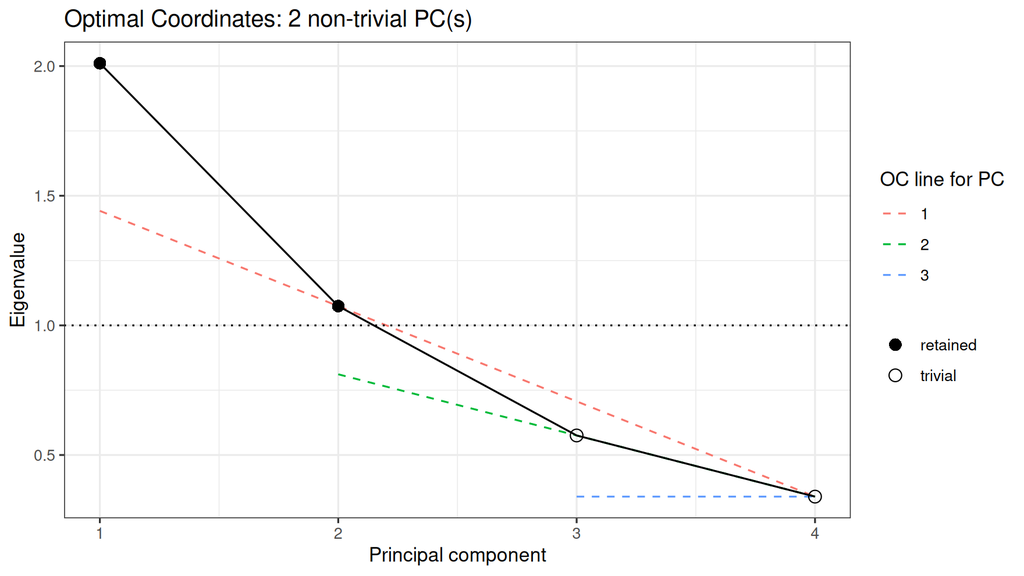

```r
plot_oc(x)
```

A PC is retained if its eigenvalue is at least 1 (Kaiser-Guttman) and at least the value predicted by the line through the following eigenvalues (Optimal Coordinates). Model selection criteria such as AIC are not suitable here: the composition is not independent of the response, so they select too many PCs.

### What do the PCs and clusters represent?

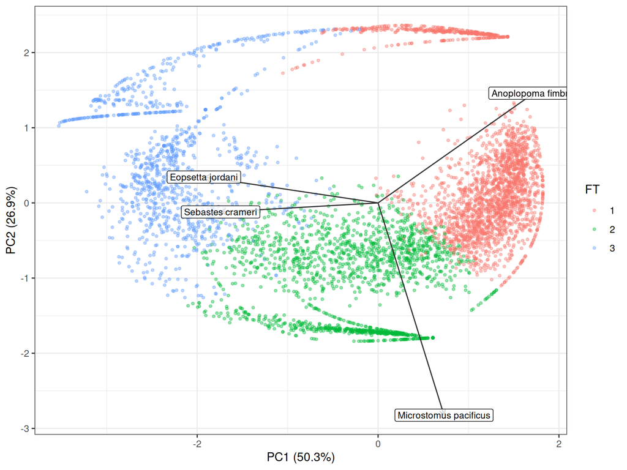

```r
plot_biplot(x)
```

```r
tactic_table(x)
```

```
##   FT operations share              dominant Microstomus pacificus
## 1  1       6009 0.470    Anoplopoma fimbria                  32.2
## 2  2       4071 0.318 Microstomus pacificus                  73.5
## 3  3       2718 0.212      Eopsetta jordani                   6.9
##   Sebastes crameri Anoplopoma fimbria Eopsetta jordani
## 1              0.1               67.1              0.5
## 2              3.4               11.8             11.3
## 3              8.5                1.3             83.4
```

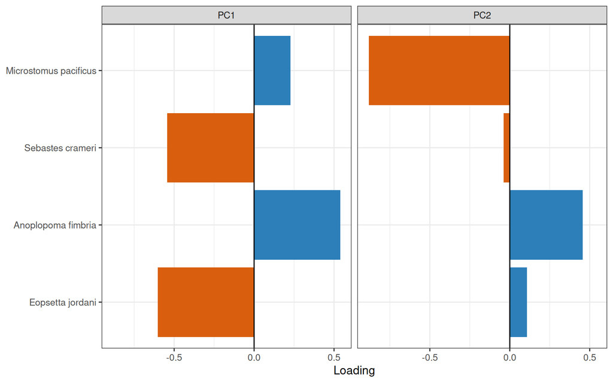

```r
pt <- plot_targeting(x, by = "month", res = 5)
pt$loadings
```

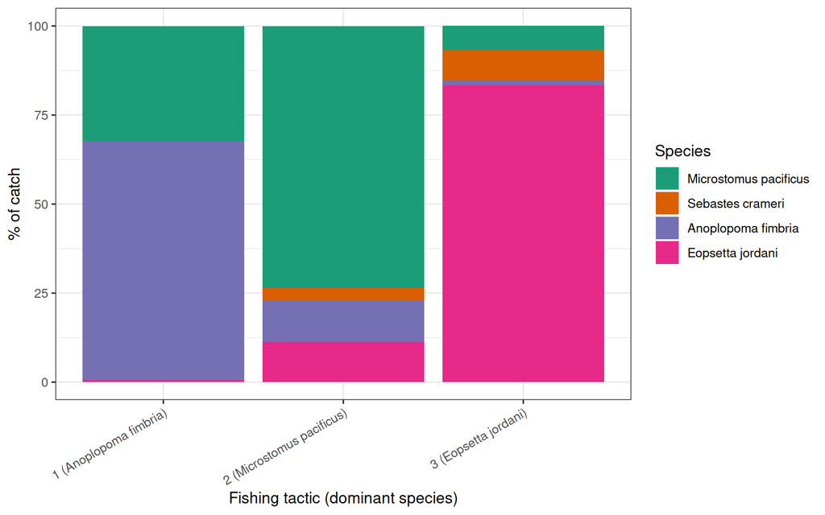

```r
pt$composition
```

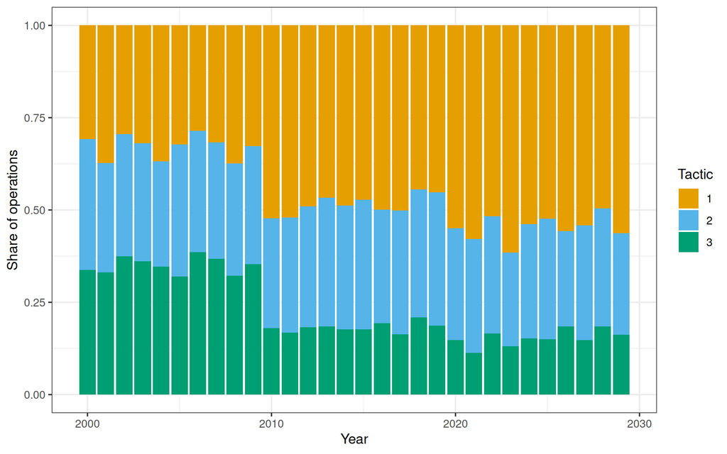

```r
pt$time
```

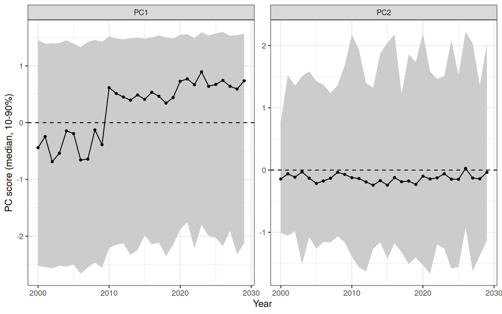

```r
pt$pcs_time
```

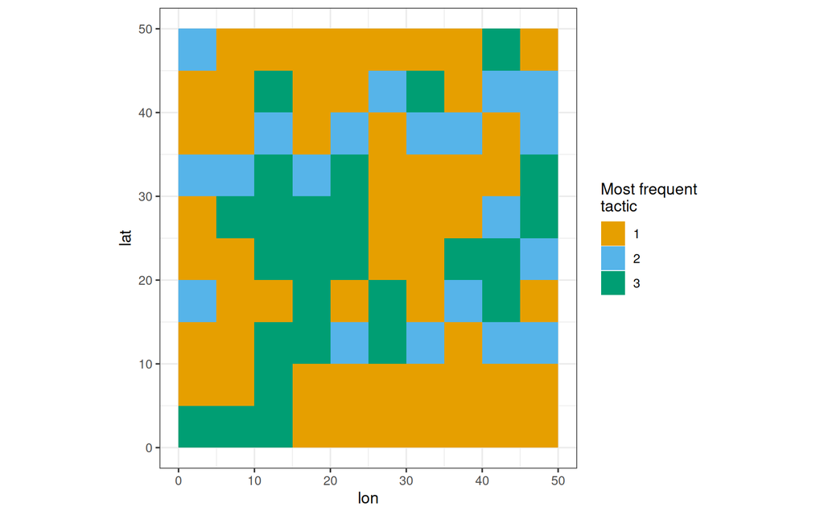

```r
pt$map_tactic
```

In this simulation, the shares of tactics should change at the price changes of 2010 and 2020: this is the targeting that the nominal CPUE cannot separate from abundance.

> **Guidelines**
> - **Name the tactics** after their dominant species (`tactic_table()`) and check that they make sense to people who know the fishery.
> - **Continuous or discrete?** PCs (DPC) represent gradual changes and mixtures of tactics; clusters assume distinct tactics. Gear-defined tactics favour clusters; continuous habitat gradients favour PCs.
> - **Diverging abundance trends.** When the relative abundance of species changes strongly, the catch composition also carries an abundance signal. PCs can then absorb part of the true trend of the species whose relative abundance changes most, and more PCs absorb more. Coarser clusters are less affected. Compare indices with 1, 2 and `n_pc` PCs and with clusters, and be cautious when they differ.
> - **Robustness.** Compare clustering methods (`method = "kmeans"`, `"hclust"`), the input (`on = "pcs"`), and the species set from Step 3.
> - Run `add_targeting()` **after** the last subsetting step; PCs and clusters depend on the operations included.

### Removing irrelevant tactics (optional)

When the fleet uses tactics that cannot catch the species of interest (e.g. pelagic trolling for a demersal species), these trips add zeros that carry no information on its abundance, and the PCA spends its first axes on the contrast with them. `select_tactics()` removes clusters, by number or by species content, and recomputes the PCA and clusters on the remaining operations:

```r
tactic_table(x)                       # identify the irrelevant cluster(s)
x2 <- select_tactics(x, drop = 3)     # by number, or by species content:
x2 <- select_tactics(x, species = c("Sp A", "Sp B"), min_share = 0.5)
tactic_table(x2)
```

> - Select on a **group of species**, not on the target alone: the clusters come from the catch composition, so selecting clusters rich in the target would select operations by their catch of the target.
> - Removed clusters should be clearly different, not borderline; check the share removed by year and compare the index with and without the selection.

## Step 7. Fit the standardisation models

`fit_cpue()` fits a set of GAMs (`mgcv`) to the CPUE of one species and derives an annual index from each. Every model contains the year effect and differs in how it accounts for targeting:

| Model | Terms besides year |
| --- | --- |
| `Base` | none |
| `Covariates` | `terms` you give (e.g. month, port, gear) |
| `DPC` | `terms` + smooths of the first `n_pc` PC scores |
| `Cluster` | `terms` + fishing tactic (`FT`) as a factor |
| `...+S` | adds a smoother of the reported positions |

`vessel = TRUE` adds a random vessel intercept to every model. The default family is Tweedie, whose power parameter is estimated together with the model (also with random vessel effects); delta-lognormal and delta-gamma models are alternatives.

Here we standardise the deep-water species, whose price rises over the three decades so that it is targeted more and more.

```r
fit <- fit_cpue(x, species = "Anoplopoma fimbria",
                models = c("Base", "Base+S", "Cluster+S", "DPC", "DPC+S"),
                vessel = TRUE, spatial_k = 30, engine = "bam")
fit
```

```
## <cpue_fit> Anoplopoma fimbria - tweedie with random vessel effects
##   operations: 12798 ; years: 2000 - 2029
##   index averaged over: FT (and positions in spatial models)
## Models:
##   Base         y ~ fyear + s(vessel_re, bs = "re")
##   Base+S       y ~ fyear + s(pos_x, pos_y, k = 30) + s(vessel_re, bs = "re")
##   Cluster+S    y ~ fyear + s(pos_x, pos_y, k = 30) + FT + s(vessel_re, bs = "re")
##   DPC          y ~ fyear + s(PC1, k = 4) + s(PC2, k = 4) + s(vessel_re, bs = "re")
##   DPC+S        y ~ fyear + s(pos_x, pos_y, k = 30) + s(PC1, k = 4) + s(PC2, k = 4) + s(vessel_re, bs = "re")
```

The index of each year is the expected CPUE averaged over a reference set of covariate values: all observed positions, the fishing tactics (and months, if in the model), the median PC scores, and the average vessel.

> **Guidelines**
> - Add terms **in a meaningful order** (e.g. Base, then space, then targeting) so that the step plot shows what each term does.
> - For a seasonal effect use a cyclic smoother: `terms = 's(month, bs = "cc", k = 8)', knots = list(month = c(0.5, 12.5))`.
> - Use `engine = "bam"` for large data sets (tens of thousands of operations or more).
> - With many zeros and no clear separation between “could not catch” and “did not catch”, Tweedie is a natural default; compare with a delta model (`family = "delta_lognormal"`) when the proportion of positive catches changes strongly over time.

## Step 8. Diagnostics

### Model comparison

```r
cpue_diagnostics(fit)
```

```
##       model component     n     AIC     BIC dev_explained  edf tweedie_p
## 1      Base      main 12798 72329.4 72769.7        0.0325 56.9     1.717
## 2    Base+S      main 12798 69995.0 70651.3        0.1698 85.8     1.690
## 3 Cluster+S      main 12798 60591.5 61255.4        0.5740 86.7     1.594
## 4       DPC      main 12798 49218.1 49712.9        0.8145 64.3     1.549
## 5     DPC+S      main 12798 49167.8 49816.6        0.8158 84.3     1.548
##   vessel_sd    dAIC
## 1     0.226 23161.6
## 2     0.224 20827.3
## 3     0.214 11423.8
## 4     0.190    50.4
## 5     0.190     0.0
```

AIC and BIC are only comparable between models with the same data and family, and they tend to favour many targeting terms because the catch composition is not independent of the response. Use them together with the following plots.

### Indices and steps

Since the data are simulated, the true biomass trend is known and can be added to the plot.

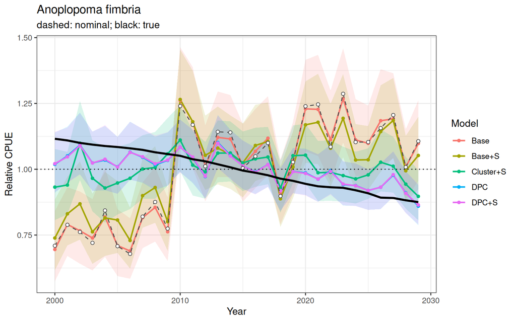

```r
truth <- data.frame(year = 1:30 + 1999,
                    true = sim$Biomass$True[sim$Biomass$Sp == "Sp4"])
plot_index(fit, true = truth)
```

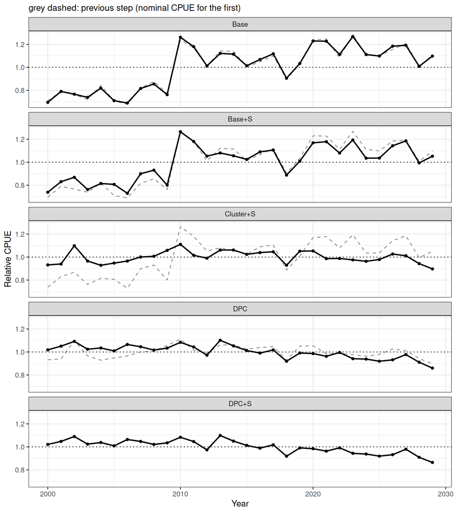

```r
plot_step(fit)
```

### Influence

The influence of a term in a year is the ratio between the expected CPUE given that year’s covariate values and given the values of all years (Bentley et al. 2012). A term that changes the index has influence that changes over time.

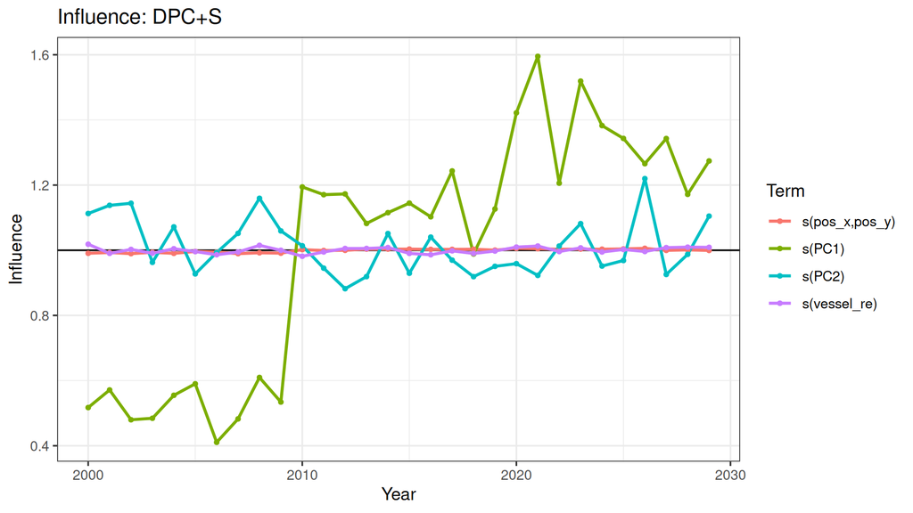

```r
plot_influence(fit, "DPC+S")
```

### Residuals, effects and vessels

For Tweedie models the residuals are randomised quantile residuals, which should be standard normal if the model fits, despite the zeros.

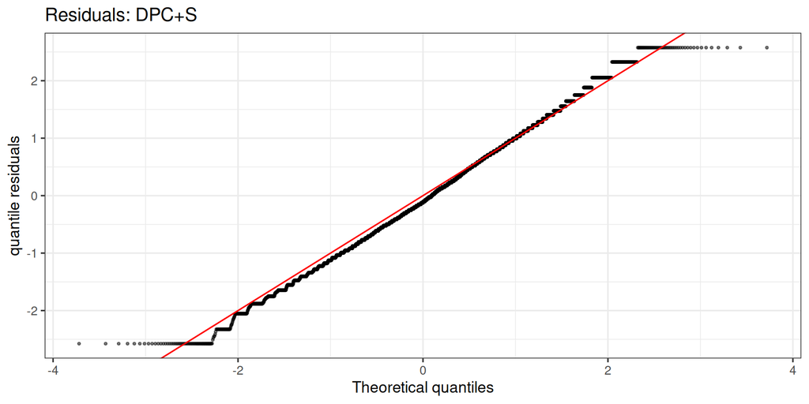

```r
res <- plot_residuals(fit, "DPC+S", by = "FT")
res$qq
```

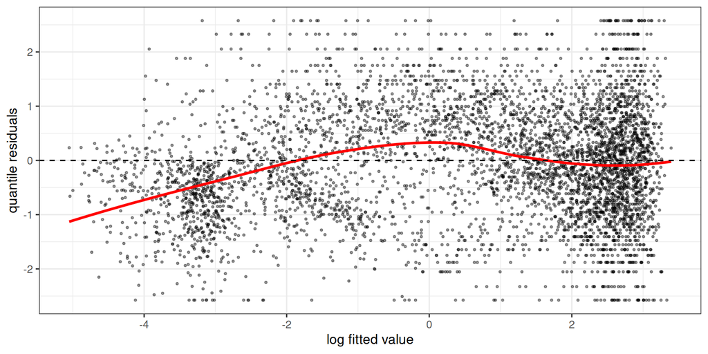

```r
res$fitted
```

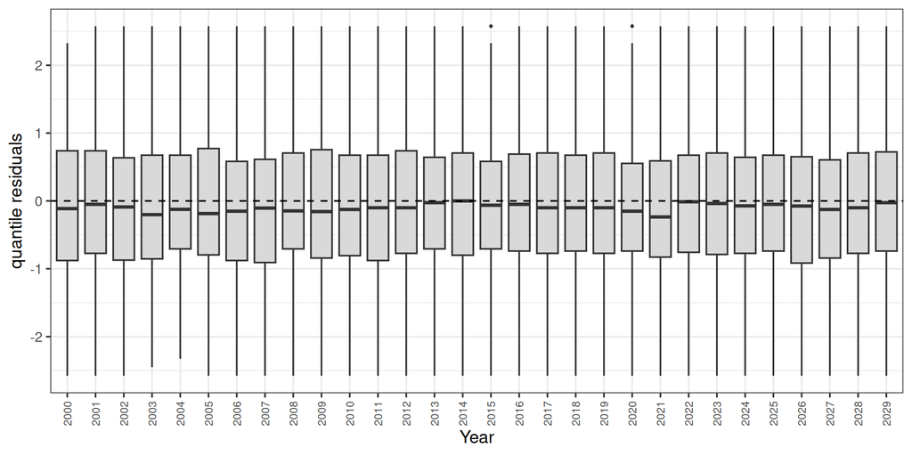

```r
res$year
```

### Predictive check of the error distribution

Residuals check each observation against its own predicted distribution. A predictive check asks whether the fitted error distribution reproduces the data **as a whole**: the share of zeros, the upper tail and the shape of the positive catches. `ppc_cpue()` simulates replicate data sets from each fitted model: for every operation the expected CPUE is computed (with the coefficients drawn from their approximate posterior, so parameter uncertainty is included) and a new value is drawn from the fitted Tweedie (or delta) distribution. Each replicate is summarised like the observed data, and the spread across replicates gives a 95% envelope. This is an approximate posterior predictive check (Gelman et al. 1996); with `param_uncertainty = FALSE` it is a plug-in (parametric bootstrap) check.

```r
pp <- ppc_cpue(fit, models = c("Base", "DPC+S"), n_sim = 50)
pp
```

```
## Predictive check: 50 replicates, with parameter uncertainty, tweedie
##
##  model  stat observed median  lower  upper tail_prob
##   Base zeros    0.151  0.125  0.117  0.129      0.00
##   Base  mean    6.520  6.500  6.270  6.760      0.46
##   Base   q90   19.900 18.900 18.300 19.500      0.00
##   Base   q99   37.300 41.400 39.200 43.500      1.00
##  DPC+S zeros    0.151  0.114  0.109  0.120      0.00
##  DPC+S  mean    6.520  6.600  6.490  6.650      0.90
##  DPC+S   q90   19.900 19.500 19.100 19.800      0.00
##  DPC+S   q99   37.300 34.400 33.000 35.800      0.00
```

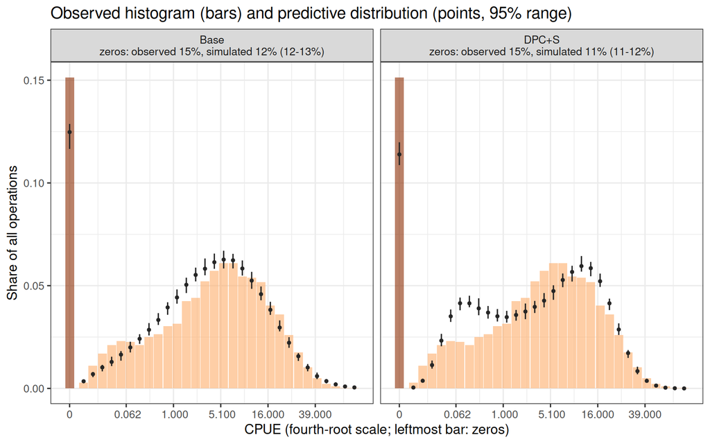

```r
pp$plots$distribution
```

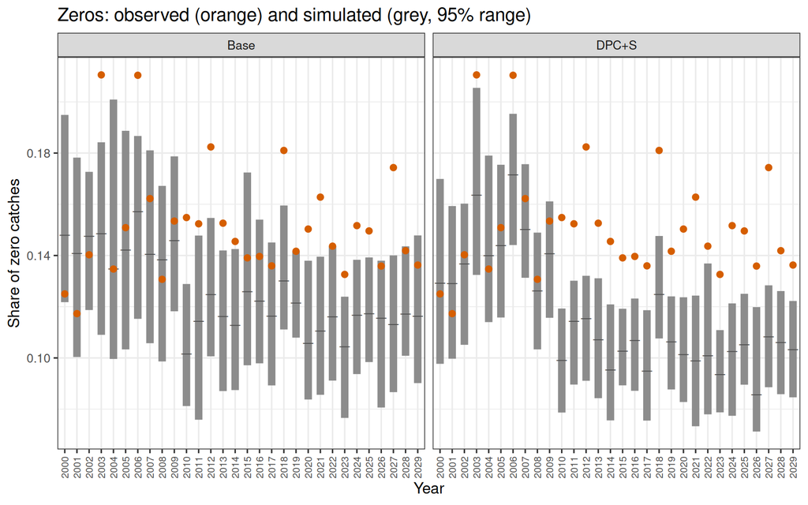

```r
pp$plots$zeros
```

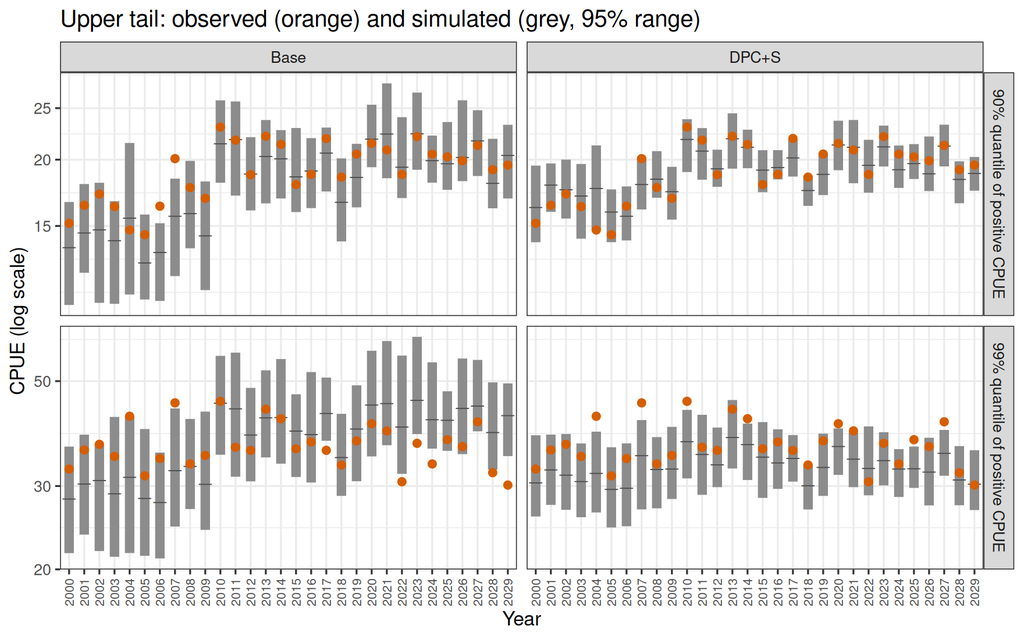

```r
pp$plots$tails
```

How to read it:

- **Zeros** observed above the envelope: the model predicts too few zeros (e.g. a Poisson-type or lognormal-type error); below: too many.
- **Upper quantiles** observed below the envelope: the model’s tail is too heavy (e.g. a negative binomial or a lognormal with large variance); above: too light.
- **Histogram of CPUE, zeros included** (`pp$plots$distribution`): observed bars (the zero bar leftmost) against the predictive distribution (points with 95% ranges). Systematic departures point to the wrong distribution or power parameter. CPUE spans orders of magnitude, so the histogram is on a fourth-root scale by default (zero stays next to the small catches); `scale = "log"` shows the shape of the positive catches best, with the zeros as a separate bar, and `scale = "raw"` the untransformed values.
- **By year.** Pooled over all operations, errors in opposite directions can cancel. The year effect fixes the mean CPUE of each year, not its zeros: a model without targeting covariates gives every operation in a year the same expected catch and gets the zeros wrong in years when the fleet fished elsewhere. A good targeting term brings the observed zeros inside the envelope. Other groupings: `by = "FT"`, `by = "month"`.
- `tail_prob` is the share of replicates at least as large as the observed value; values near 0 or 1 flag misfit.
- Information criteria cannot compare a Tweedie with a delta model; a predictive check can.

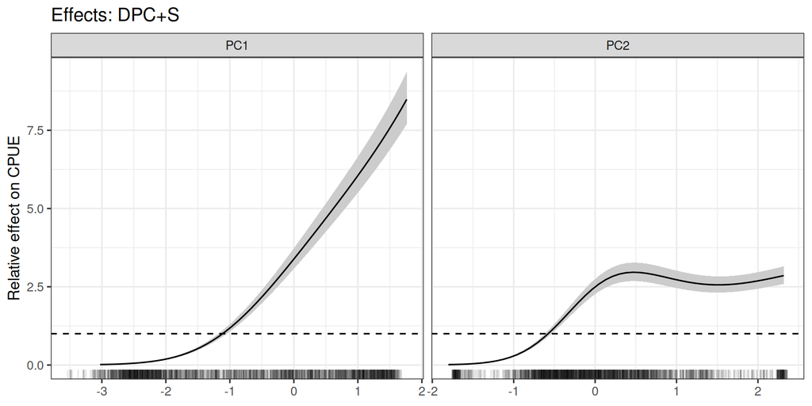

```r
eff <- plot_effects(fit, "DPC+S")
eff$numeric
```

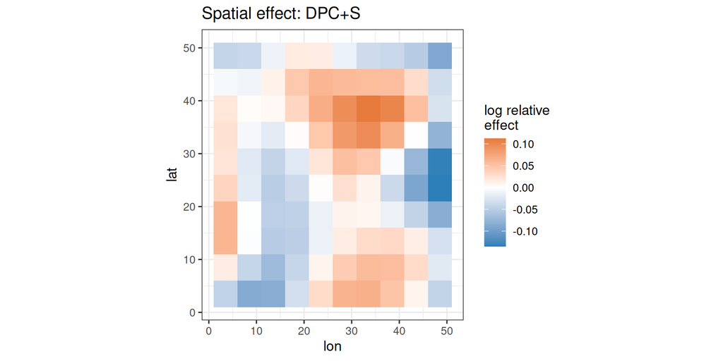

```r
eff$space
```

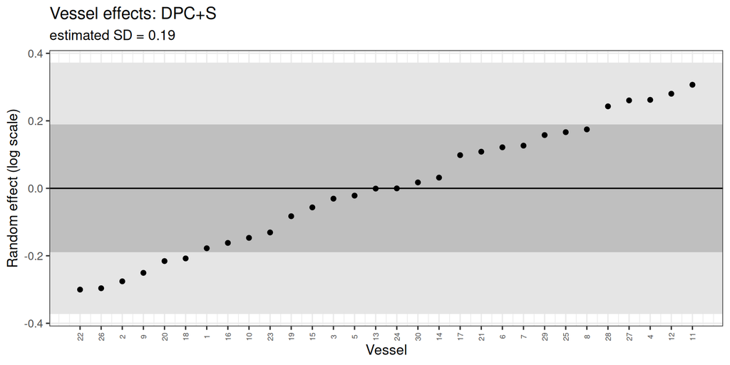

```r
plot_vessel_effects(fit, "DPC+S")
```

> **Guidelines**
> - Check the **influence** of the targeting terms: a strong trend in influence means targeting changed and the term corrects for it.
> - Check that residuals show **no trend by year** and no pattern against the targeting covariates or tactics.
> - Check that the error distribution reproduces the **zeros and the upper tail by year** (`ppc_cpue()`).
> - Compare the **DPC and Cluster** indices. If they disagree, look at what the PCs capture over time (Step 6) and whether the species’ relative abundances may have diverged.

## Step 9. The final index

```r
cpue_index(fit, "DPC+S")
```

```
##    year   n  nominal    index  relative     se_log         cv     lower
## 1  2000 240 4.510639 7.799805 1.0211187 0.05723977 0.05728669 0.9127519
## 2  2001 341 5.015292 8.000362 1.0473748 0.05119003 0.05122359 0.9473889
## 3  2002 278 4.842745 8.325937 1.0899977 0.05467163 0.05471251 0.9792378
## 4  2003 266 4.580052 7.820604 1.0238416 0.05604453 0.05608857 0.9173323
## 5  2004 193 5.362843 7.928239 1.0379327 0.06021755 0.06027218 0.9223824
## 6  2005 285 4.500457 7.704467 1.0086373 0.05456156 0.05460220 0.9063403
## 7  2006 347 4.314219 8.127375 1.0640027 0.05265772 0.05269425 0.9596648
## 8  2007 413 5.213270 8.000547 1.0473990 0.04979724 0.04982812 0.9500006
## 9  2008 329 5.567656 7.800039 1.0211493 0.05097000 0.05100312 0.9240654
## 10 2009 391 4.924253 7.903036 1.0346332 0.04996733 0.04999854 0.9381092
## 11 2010 394 7.885983 8.275977 1.0834572 0.04696518 0.04699109 0.9881757
## 12 2011 315 7.431699 7.991093 1.0461612 0.04932446 0.04935447 0.9497576
## 13 2012 477 6.431612 7.435989 0.9734893 0.04580820 0.04583224 0.8898944
## 14 2013 439 7.263159 8.394664 1.0989952 0.04631051 0.04633535 1.0036342
```

[output cut: 47 more lines]

```r
export_index(fit, "cpue_index_DPC.csv", model = "DPC+S")
```

`index` is in the units of the data (CPUE at the reference covariate values), `relative` is scaled to its mean, and `se_log` is the standard error of the log index, the usual input to stock assessment models.

## Processing log

The log records every step, how many operations it removed, and the settings used.

```r
x$log
```

```
##                                         step operations
## 1                        input (long format)      12799
## 2                             select species      12799
## 3 remove operations without selected species      12798
## 4                              add targeting      12798
##                                                           note
## 1                                     44049 records, 6 species
## 2                     4 of 6 species kept (occurrence >= 0.95)
## 3               zero catch of all selected species (1 removed)
## 4 2 PC(s) used (OC test: 2), 3 clusters (clara on composition)
```

## Reporting checklist

| Item | Report |
| --- | --- |
| Operation and effort | unit (set, trip, …), effort measure |
| Data selection | all subsetting rules and the processing log |
| Species set | threshold, criterion (occurrence or weight), species kept |
| Fleet | indicator-fleet rules (activity and target species), number of vessels |
| Subsetting | Stephens & MacCall target, critical value, share kept over time; tactics removed (`select_tactics()`) |
| Targeting | transformation, eigenvalues, OC result, number of PCs and clusters, clustering method, tactic composition |
| Models | family, terms of each model, random effects, reference set of the index |
| Diagnostics | model table, step and influence plots, residuals, predictive check (zeros and tails by year), vessel effects |
| Index | table with nominal and standardised CPUE, log SE and CV |
| Sensitivity | indices with alternative species sets, numbers of PCs, clusters, families |

## References

Bentley, N., Kendrick, T.H., Starr, P.J. and Breen, P.A. (2012) Influence plots and metrics: tools for better understanding fisheries catch-per-unit-effort standardizations. ICES Journal of Marine Science 69: 84-88.

Dunn, P.K. and Smyth, G.K. (1996) Randomized quantile residuals. Journal of Computational and Graphical Statistics 5: 236-244.

Gelman, A., Meng, X.-L. and Stern, H. (1996) Posterior predictive assessment of model fitness via realized discrepancies. Statistica Sinica 6: 733-807.

Hoyle, S.D., Langley, A.D. and Campbell, R.A. (2014) Recommended approaches for standardizing CPUE data from pelagic fisheries. WCPFC-SC10-2014/SA-IP-10.

Stephens, A. and MacCall, A. (2004) A multispecies approach to subsetting logbook data for purposes of estimating CPUE. Fisheries Research 70: 299-310.

Winker, H., Kerwath, S.E. and Attwood, C.G. (2013) Comparison of two approaches to standardize catch-per-unit-effort for targeting behaviour in a multispecies hand-line fishery. Fisheries Research 139: 118-131.

Winker, H., Kerwath, S.E. and Attwood, C.G. (2014) Proof of concept for a novel procedure to standardize multispecies catch and effort data. Fisheries Research 155: 149-159.